# POTS in Long COVID: A Subgroup Comparison

## 3. Treatment Burden: POTS Patients Try More, Get Less

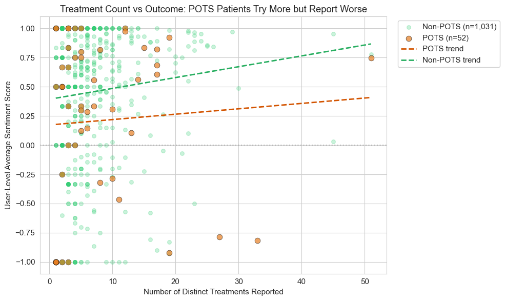

**Treatment count comparison:**

- POTS mean: 8.1 treatments | Non-POTS mean: 4.2 treatments

- Mann-Whitney p=0.0001, rank-biserial r=-0.313 — POTS patients try significantly more treatments

- Within POTS: Spearman rho=0.194, p=0.167 — positive correlation (more treatments, better outcomes) between treatment count and outcome

**Plain language:** POTS patients try roughly twice as many treatments as other Long COVID patients. The relationship between treatment count and outcomes is weak in the POTS group.

The scatter plot reveals a striking asymmetry: non-POTS users cluster in the upper-left (fewer treatments, good outcomes), while POTS users spread across the x-axis with many landing below zero. The trend lines tell the story -- non-POTS patients generally do well regardless of how many treatments they try, while POTS patients show a more complex relationship with treatment burden.

## 4. Condition Co-occurrence: What Else Do POTS Patients Have?

POTS rarely travels alone. Understanding co-occurring conditions helps explain why treatment is harder and which therapeutic targets might matter most. We compare co-occurrence rates in POTS vs non-POTS users, excluding "long covid" (the community-defining condition) and generic/redundant terms.

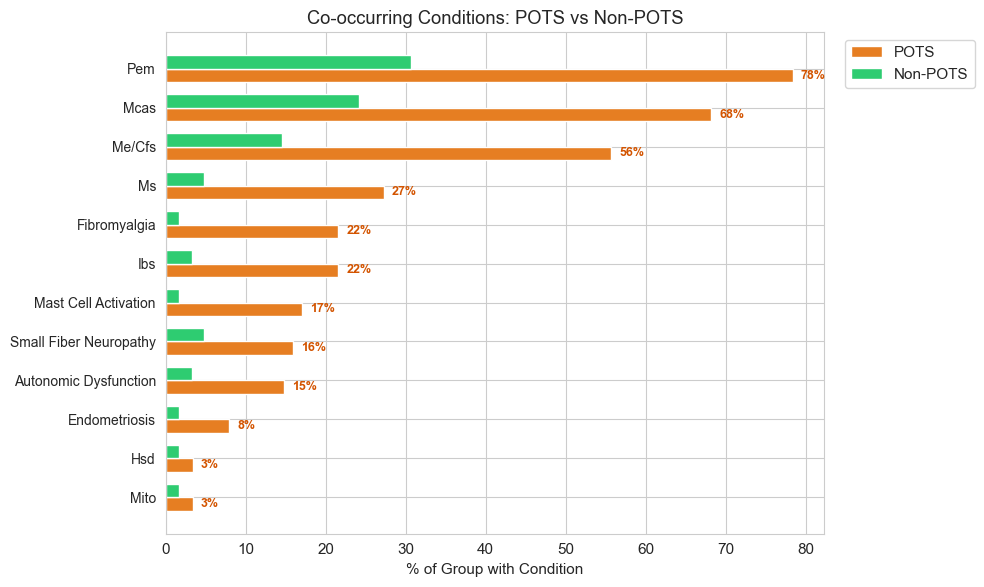

## 5. Treatment-Level Analysis: What Works Differently for POTS?

The overall outcome gap is clear. Now we ask: which specific treatments drive this difference? We compare positive rates for every treatment with at least 3 POTS reporters and at least 5 non-POTS reporters, using Fisher's exact test for each comparison.

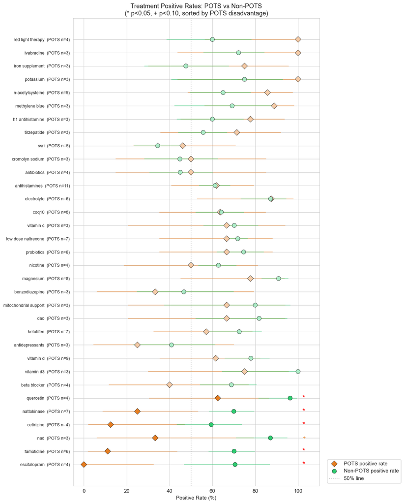

Treatment Comparison: Largest POTS vs Non-POTS Differences

| Treatment | POTS n | POTS Rate | NP n | Non-POTS Rate | Difference | Fisher p | Cohen's h |
| --- | --- | --- | --- | --- | --- | --- | --- |
| escitalopram | 4 | 0% [0%-32%] | 10 | 71% [47%-87%] | -71% | 0.002 | -1.93 |
| famotidine | 6 | 11% [2%-44%] | 48 | 70% [58%-80%] | -59% | 0.001 | -1.31 |
| nad | 3 | 33% [6%-79%] | 22 | 87% [71%-95%] | -54% | 0.074 | -1.18 |
| cetirizine | 4 | 12% [2%-47%] | 29 | 59% [43%-74%] | -47% | 0.022 | -1.04 |
| nattokinase | 7 | 25% [9%-53%] | 43 | 70% [58%-79%] | -45% | 0.007 | -0.94 |
| quercetin | 4 | 62% [31%-86%] | 24 | 96% [82%-99%] | -34% | 0.030 | -0.93 |
| beta blocker | 4 | 40% [12%-77%] | 33 | 69% [54%-80%] | -29% | 0.321 | -0.59 |
| vitamin d3 | 3 | 75% [30%-95%] | 7 | 100% [65%-100%] | -25% | 0.364 | -0.98 |
| vitamin d | 9 | 62% [36%-82%] | 51 | 78% [66%-87%] | -16% | 0.289 | -0.36 |
| antidepressants | 3 | 25% [5%-70%] | 22 | 41% [23%-61%] | -16% | 1.000 | -0.34 |
| ketotifen | 7 | 57% [33%-79%] | 30 | 73% [59%-83%] | -15% | 0.332 | -0.32 |
| dao | 3 | 67% [21%-94%] | 11 | 82% [52%-95%] | -15% | 1.000 | -0.35 |
| mitochondrial support | 3 | 67% [21%-94%] | 5 | 80% [38%-96%] | -13% | 1.000 | -0.30 |
| benzodiazepine | 3 | 33% [6%-79%] | 13 | 47% [25%-70%] | -13% | 1.000 | -0.27 |
| magnesium | 8 | 78% [45%-94%] | 65 | 91% [83%-95%] | -13% | 0.232 | -0.37 |
| nicotine | 4 | 50% [19%-81%] | 78 | 63% [54%-71%] | -13% | 0.672 | -0.26 |
| probiotics | 6 | 67% [35%-88%] | 40 | 75% [62%-84%] | -8% | 0.690 | -0.17 |
| low dose naltrexone | 7 | 67% [35%-88%] | 176 | 72% [67%-76%] | -5% | 0.716 | -0.11 |
| vitamin c | 3 | 67% [21%-94%] | 38 | 70% [56%-81%] | -4% | 1.000 | -0.08 |
| coq10 | 8 | 64% [35%-85%] | 54 | 64% [52%-75%] | -1% | 1.000 | -0.01 |
| electrolyte | 6 | 88% [53%-98%] | 34 | 87% [73%-94%] | +0% | 1.000 | 0.01 |
| antihistamines | 11 | 62% [41%-79%] | 105 | 61% [54%-68%] | +1% | 1.000 | 0.01 |
| antibiotics | 4 | 50% [15%-85%] | 30 | 45% [31%-60%] | +5% | 1.000 | 0.10 |
| cromolyn sodium | 3 | 50% [15%-85%] | 20 | 45% [28%-62%] | +5% | 1.000 | 0.10 |
| ssri | 5 | 46% [23%-71%] | 45 | 34% [24%-47%] | +12% | 0.528 | 0.24 |
| tirzepatide | 3 | 71% [36%-92%] | 39 | 56% [44%-67%] | +16% | 0.692 | 0.33 |
| h1 antihistamine | 3 | 78% [45%-94%] | 29 | 60% [44%-74%] | +18% | 0.450 | 0.39 |
| methylene blue | 3 | 89% [56%-98%] | 10 | 69% [42%-87%] | +20% | 0.360 | 0.50 |
| n-acetylcysteine | 5 | 86% [49%-97%] | 36 | 65% [50%-78%] | +21% | 0.404 | 0.49 |
| potassium | 3 | 100% [44%-100%] | 8 | 75% [41%-93%] | +25% | 1.000 | 0.98 |
| iron supplement | 3 | 75% [30%-95%] | 14 | 48% [28%-68%] | +27% | 0.593 | 0.57 |
| ivabradine | 3 | 100% [44%-100%] | 23 | 72% [56%-84%] | +28% | 0.556 | 1.05 |
| red light therapy | 4 | 100% [57%-100%] | 17 | 60% [39%-78%] | +40% | 0.140 | 1.31 |

The forest plot tells a clear story: for most treatments, the POTS dot (diamond) sits to the left of the non-POTS dot (circle), confirming that POTS patients generally get less benefit from the same treatments. However, a few treatments buck this trend -- these are the ones worth investigating further.